# Publicidad y ventas

## Advertising and Sales

El dataset usado en este documento presenta datos relacionados entre la publicidad y las ventas. Este dataset se puede encontrar en [Kaggle](https://www.kaggle.com/sazid28/advertising.csv), tiene una usabilidad de 4.1 en una escala de 1 a 10 en relación a la faciidad de entendimiento e incluye metadatos esenciales, la puntuación se otorga porque solo cuenta con etiquetas, nombre de las columnas, licencia especifica, formatos de archivo aceptables para ser usados y un núcleo público. Tiene un data explorer de 4.64 KB, y en el summary se especifica que hace parte de un único archivo con 5 columnas. Entre las tags especificadas esta business services y por ahora tiene 10 kernels. El creador es el usuario de Kaggle Sagidur Rahman quien hizo la última actualización en el 2018.

## GGPLOT2

ggplot2 es una visualización de datos de paquete para la programación estadística lenguaje R . Creado por Hadley Wickham en 2005, ggplot2 es una implementación de la Gramática de gráficos de Leland Wilkinson , un esquema general para la visualización de datos que divide los gráficos en componentes semánticos como escalas y capas. ggplot2 puede servir como un reemplazo para los gráficos base en R y contiene una serie de valores predeterminados para la visualización web e impresa de escalas comunes. Desde 2005, ggplot2 ha crecido en uso para convertirse en uno de los paquetes R más populares. Está licenciado bajo GNU GPL v2. Su instalación requiere del siguiente comando:

`install.packages("ggplot2")`

Otros paquetes instalados:

`install.packages("coefplot")`

En primer lugar importamos la libreria GGPLOT2:

```r
library(ggplot2)
library(coefplot)
```

## Exploración

Realizamos la lectura del dataframe Advertising, que se encuentra en formato csv o archivo separado por comas.

```r
#Leemos el archivo en formato de tabla y creamos un marco de datos y crea un marco de datos.
ObjDataset=read.table("Advertising.csv",header=T,sep=",")
#Adjuntamos la base de datos a la ruta de busqueda
attach(ObjDataset)
#Obtenemos los nombres de los objetos del dataset
names(ObjDataset)
```

```
[1] "X"         "TV"        "radio"     "newspaper" "sales"
```

Realizamos una pre-visualizacion del dataset

```r
#Devolvemos la primera parte del dataset
head(ObjDataset)
```

|  | X | TV | radio | newspaper | sales |
| --- | --- | --- | --- | --- | --- |
| 1 | 1 | 230.1 | 37.8 | 69.2 | 22.1 |
| 2 | 2 | 44.5 | 39.3 | 45.1 | 10.4 |
| 3 | 3 | 17.2 | 45.9 | 69.3 | 9.3 |
| 4 | 4 | 151.5 | 41.3 | 58.5 | 18.5 |
| 5 | 5 | 180.8 | 10.8 | 58.4 | 12.9 |
| 6 | 6 | 8.7 | 48.9 | 75.0 | 7.2 |

Observamos caracteristicas basicas del dataset:

```r
#Devolvemos una estimacion de la memoria necesaria que usa R para almacenar el dataset
object.size(ObjDataset)
```

```
8432 bytes
```

```r
#Devolvemos la dimension del dataset
dim(ObjDataset)
```

```
[1] 200   5
```

```r
#Mostramos la forma compacta del dataset
str(ObjDataset)
```

```
'data.frame':   200 obs. of  5 variables:
 $ X        : int  1 2 3 4 5 6 7 8 9 10 ...
 $ TV       : num  230.1 44.5 17.2 151.5 180.8 ...
 $ radio    : num  37.8 39.3 45.9 41.3 10.8 48.9 32.8 19.6 2.1 2.6 ...
 $ newspaper: num  69.2 45.1 69.3 58.5 58.4 75 23.5 11.6 1 21.2 ...
 $ sales    : num  22.1 10.4 9.3 18.5 12.9 7.2 11.8 13.2 4.8 10.6 ...
```

```r
#Mostramos la forma compacta de la columna TV
str(X)
```

```
 int [1:200] 1 2 3 4 5 6 7 8 9 10 ...
```

```r
#Mostramos la forma compacta de la columna TV
str(TV)
```

```
 num [1:200] 230.1 44.5 17.2 151.5 180.8 ...
```

```r
#Mostramos la forma compacta de la columna radio
str(radio)
```

```
 num [1:200] 37.8 39.3 45.9 41.3 10.8 48.9 32.8 19.6 2.1 2.6 ...
```

```r
#Mostramos la forma compacta de la columna newspaper
str(newspaper)
```

```
 num [1:200] 69.2 45.1 69.3 58.5 58.4 75 23.5 11.6 1 21.2 ...
```

```r
#Mostramos la forma compacta de la columna sales
str(sales)
```

```
 num [1:200] 22.1 10.4 9.3 18.5 12.9 7.2 11.8 13.2 4.8 10.6 ...
```

```r
#Retornamos el tipo de dato de la columna X
class(X)
```

```
[1] "integer"
```

```r
#Retornamos el tipo de dato de la columna TV
class(TV)
```

```
[1] "numeric"
```

```r
#Retornamos el tipo de dato de la columna radio
class(radio)
```

```
[1] "numeric"
```

```r
#Retornamos el tipo de dato de la columna newspaper
class(newspaper)
```

```
[1] "numeric"
```

```r
#Retornamos el tipo de dato de la columna Target (sales)
class(sales)
```

```
[1] "numeric"
```

```r
#Observamos si faltan datos
head(is.na(ObjDataset))
```

```
         X    TV radio newspaper sales
[1,] FALSE FALSE FALSE     FALSE FALSE
[2,] FALSE FALSE FALSE     FALSE FALSE
[3,] FALSE FALSE FALSE     FALSE FALSE
[4,] FALSE FALSE FALSE     FALSE FALSE
[5,] FALSE FALSE FALSE     FALSE FALSE
[6,] FALSE FALSE FALSE     FALSE FALSE
```

La variables ventas (sales) sera tomada como la variable objetivo o target.

```r
#colnames(ObjDataset)[5]="Target"
```

```r
#Retornamos el tipo de dato de la columna Target (sales)
class(sales)
```

```
[1] "numeric"
```

## Analísis estadístico

### Media

Es la media aritmética o promedio de los valores de una variable. Es decir la suma de los valores dividido por el tamaño muetral.

### Mediana

Es un valor que divide a las observaciones en dos grupos con el mismo número de individuos(percentil 50). Si el número de datos es par, se elige la media de los dos datos centrales.

### Cuartil

Son los tiles que se multiplican por un cuarto de un conjunto de datos.

### Primer cuartil

La mediana de la primera mitad de valores.

### Segundo cuartil

La propia mediana de la serie.

### Tercer cuartil

La mediana de la segunda mitad de valores.

### Valores máximo y mínimo

Los valores máximo y mínimo de un conjunto de datos se obtienen con las funciones max y min.

```r
#Realizamos un resumen de la columna TV
summary(TV)
```

```
   Min. 1st Qu.  Median    Mean 3rd Qu.    Max.
   0.70   74.38  149.75  147.04  218.82  296.40
```

```r
#Realizamos un resumen de la columna radio
summary(radio)
```

```
   Min. 1st Qu.  Median    Mean 3rd Qu.    Max.
  0.000   9.975  22.900  23.264  36.525  49.600
```

```r
#Realizamos un resumen de la columna newspaper
summary(newspaper)
```

```
   Min. 1st Qu.  Median    Mean 3rd Qu.    Max.
   0.30   12.75   25.75   30.55   45.10  114.00
```

```r
#Realizamos un resumen de la columna sales
summary(sales)
```

```
   Min. 1st Qu.  Median    Mean 3rd Qu.    Max.
   1.60   10.38   12.90   14.02   17.40   27.00
```

## Regresion Lineal Simple

El ajuste lineal es un modelo matemático usado para aproximar la relación de dependencia entre una variable dependiente Y, las variables independientes Xi y un término aleatorio ε.

Se procede a modelar la relación entre la Televisión (TV) y las ventas (Sales), en donde sales es la variable dependiente y TV es la variable independiente.

### Diagrama de dispersión

Es un tipo de diagrama matemático que utiliza las coordenadas cartesianas para mostrar los valores de dos variables para un conjunto de datos.

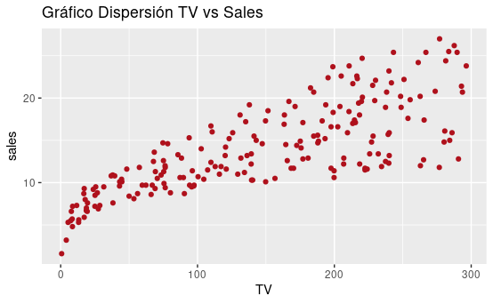

```r
#Graficar la dispersión entre ambas variables
ggplot(ObjDataset, aes(TV, sales)) +ggtitle("Gráfico Dispersión TV vs Sales")+ geom_point(color="#af111c")
```

### Correlación

Es el vínculo recíproco o correspondiente que existe entre dos o más elementos. Es decir la correlación alude a la proporcionalidad y la relación lineal que existe entre distintas variables. Si los valores de una variable se modifican de manera sistemática con respecto a los valores de otra, se dice que ambas variables se encuentran correlacionadas.

```r
#Calculo de la correlacion
cor(TV, sales)
```

```
[1] 0.7822244
```

Este resultado significa que existe un correlación positiva, es decir la relación entre las dos variables muestra que ambas aumentan simultáneamente.

### Modelo lineal

Usado en diferentes maneras de acuerdo al contexto. La manera más frecuente es en conexión con modelos de regresión y el término a menudo se toma como un sinónimo del modelo de regresión lineal.

```r
#Creamos el modelo de regresion lineal
#Variable (Y) ~ Variable (X)
Objrl=lm(sales~TV)
```

```r
#Realizamos un resumen estadistico del modelo
summary(Objrl)
```

```
Call:
lm(formula = sales ~ TV)

Residuals:
    Min      1Q  Median      3Q     Max
-8.3860 -1.9545 -0.1913  2.0671  7.2124

Coefficients:
            Estimate Std. Error t value Pr(>|t|)
(Intercept) 7.032594   0.457843   15.36   <2e-16 ***
TV          0.047537   0.002691   17.67   <2e-16 ***
---
Signif. codes:  0 ‘***’ 0.001 ‘**’ 0.01 ‘*’ 0.05 ‘.’ 0.1 ‘ ’ 1

Residual standard error: 3.259 on 198 degrees of freedom
Multiple R-squared:  0.6119,    Adjusted R-squared:  0.6099
F-statistic: 312.1 on 1 and 198 DF,  p-value: < 2.2e-16
```

*Residuals: Resumen de los residuos.

*Coeficientes: -Intercept el estimado de la intercepción. y TV el estimado de la pendiente.

*Residual standard error: Medida de variación de las observaciones alrededor de la regresión lineal (MSE: Mean Squeared Error).

*R~cuadrado: Medida estadistica de cuan cerca estan los datos de la linea de regresión. Conocida tambien coef. de determinación. Porcentaje (%) de la variación de la variable respuesta (Y/outcome) que se explica por un modelo lineal. R-cuadr = variación explicada / variación total.

*F~Statistic: test de hipotesis y pvalue: [“test que todos los coef… en el modelo sean cero”]

```r
#Mostramos los atributos del modelo
attributes(Objrl)
```

```
$names
 [1] "coefficients"  "residuals"     "effects"
 [4] "rank"          "fitted.values" "assign"
 [7] "qr"            "df.residual"   "xlevels"
[10] "call"          "terms"         "model"

$class
[1] "lm"
```

*Coeficientes del modelo: Describen el tamaño de la relación entre un predictor y la variable de respuesta. Los coeficientes son los números por los cuales se multiplican los valores del término en una ecuación de regresión.

```r
#Observamos los coeficientes del modelo
Objrl$coefficients
```

```
(Intercept)          TV
 7.03259355  0.04753664
```

*Residuos: Son las diferencias entre los valores de la variable dependiente observados y los valores que predecimos a partir de nuestra recta de regresión.

```r
#Mostramos la cabecera de los residuos del modelo
head(Objrl$residuals)
```

```
         1          2          3          4          5          6
 4.1292255  1.2520260  1.4497762  4.2656054 -2.7272181 -0.2461623
```

*Call: formula con la que obtuvimos el modelo.

```r
#Mostramos la formula con la que obtuvimos el modelo
head(Objrl$call)
```

```
lm(formula = sales ~ TV)
```

### Intervalos de confianza

Los intervalos de confianza marcan dos puntos dentro de los cuales es esperable que se encuentre el verdadero coeficiente del modelo.

```r
#Obtenemos valores de confianza
confint(Objrl)
```

```
                 2.5 %     97.5 %
(Intercept) 6.12971927 7.93546783
TV          0.04223072 0.05284256
```

```r
#Obtenemos valores de confianza
confint(Objrl,level=0.99)
```

```
                 0.5 %     99.5 %
(Intercept) 5.84179567 8.22339143
TV          0.04053867 0.05453461
```

### ANOVA

La técnica de análisis de varianza (ANOVA) también conocida como análisis factorial y desarrollada por Fisher en 1930, constituye la herramienta básica para el estudio del efecto de uno o más factores (cada uno con dos o más niveles) sobre la media de una variable continua. Es por lo tanto el test estadístico a emplear cuando se desea comparar las medias de dos o más grupos. Esta técnica puede generalizarse también para estudiar los posibles efectos de los factores sobre la varianza de una variable.

```r
#Valroes estimados
anova(Objrl)
```

```
Analysis of Variance Table

Response: sales
           Df Sum Sq Mean Sq F value    Pr(>F)
TV          1 3314.6  3314.6  312.14 < 2.2e-16 ***
Residuals 198 2102.5    10.6
---
Signif. codes:  0 ‘***’ 0.001 ‘**’ 0.01 ‘*’ 0.05 ‘.’ 0.1 ‘ ’ 1
```

Obtenemos un vector con los estimados para y o de los residuos

```r
#Valroes estimados
fitted(Objrl)
```

[output not shown]

[output cut: 13 more lines]

[output not shown]

```r
#Valroes residuos
residuals(Objrl)
```

[output not shown]

[output cut: 25 more lines]

[output not shown]

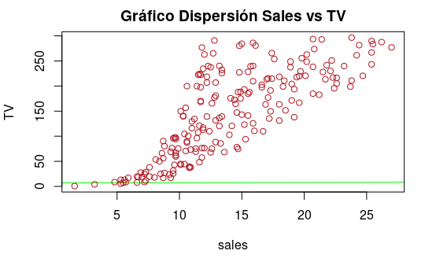

```r
plot(sales, TV, main="Gráfico Dispersión Sales vs TV", col="#af111c",abline(Objrl,col="#00FF00"))
```

```r
#Extraemos los coeficientes
coef(Objrl)
```

```
(Intercept)          TV
 7.03259355  0.04753664
```

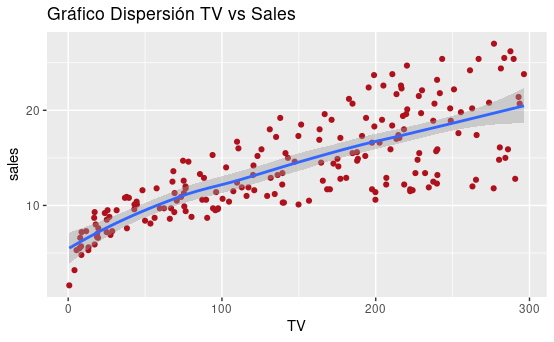

```r
ggplot(Objrl,aes(TV,sales))+ggtitle("Gráfico Dispersión TV vs Sales")+ geom_point(color="#af111c")+stat_smooth()
```

Los errores o residuos, son la diferencia entre el valor y (observado) y el valor ŷ (predicho/ajustado)

*Primer grafico: "Si se cumple el supuesto de linealidad (se observa una linea) con una nube de puntos sin ningun patron.

*Segundo grafico: qplot “CuartilCuartil grafico”,el eje Y: es el error residual ordenado y estandarizado. El Eje X son los errores residuales ordenados teoricos, para el supuesto se espera visualizar una linea diagonal.

*Tercer y Cuarto Grafico: Identifican la No-Linealidad, no varianza constante al igual que observaciones problematicas del modelo.

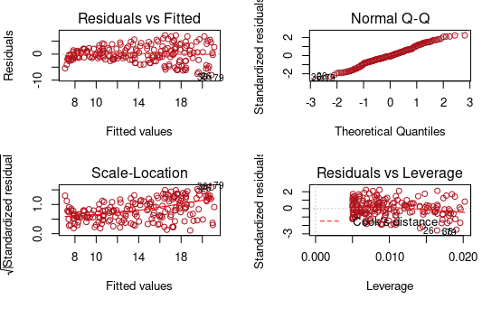

```r
par(mfrow=c(2,2))
plot(Objrl, col="#af111c")
```

### Criterio de información de Akaike

El AIC busca un balance entre la capacidad predictiva de un modelo (la varianza explicada) y la cantidad de parámetros que este debe considerar para lograr un mejor ajuste. Es decir, premia a los modelos a medida que aumentan la varianza explicada, pero simultáneamente los penaliza a medida que aumentan el número de parámetros.

```r
#Obtenemos el AIC del modelo
AIC(Objrl)
```

```
[1] 1044.091
```

```r
#Obtenemos la predicción del modelo para nuevos datos
predict(Objrl)
```

[output not shown]

[output cut: 13 more lines]

[output not shown]

En estadística, la distancia de Cook o la D de Cook es una estimación comúnmente utilizada de la influencia de un punto de datos cuando se realiza un análisis de regresión de mínimos cuadrados.

```r
#Obtenemos las distancias de Cook
cooks.distance(Objrl)
```

[output not shown]

[output cut: 25 more lines]

[output not shown]

La gráfica de los coeficientes estimados de cada variable (sola o de interacción), en cada modelo y detectar los que son diferentes de 0, y los modelos que los contienen.

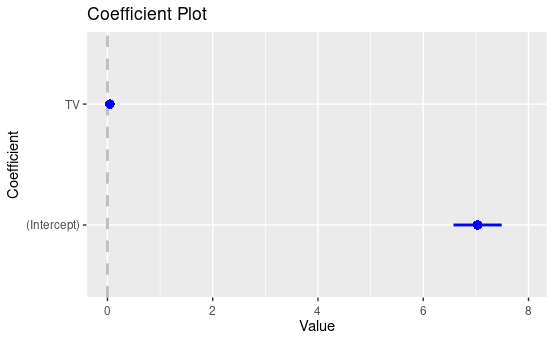

```r
#Grafico de los coeficientes
coefplot(Objrl)
```

```r
#Efectos de las variables, directos y con interacciones
head(effects(Objrl))
```

```
 (Intercept)           TV
-198.3080968   57.5727207    1.0766122    3.9921448   -2.9789267

  -0.6256367
```